# Homework #1: Supervised Learning

Nicholas Keeley

Due: Tue Sept 07 | 2:55pm

**DS 6030 | Fall 2021 | University of Virginia**

Note: On my honor, I have not given or received (uncredited) aid on this assessment. This code represents my own work. /s Nicholas Keeley

## Credits: Drew Pearson (compared density plots, and he showed me the geom_density() function)

# Required R packages and Directories

# Problem 1: Evaluating a Regression Model

## a. Create a set of functions to generate data from the following distributions:

$$\begin{align*}
X &\sim \mathcal{N}(0, 1) \\
Y &= -1 + .5X + .2X^2 + \epsilon \\
\epsilon &\sim \mathcal{N}(0,\, \sigma)
\end{align*}$$

```r
func1=function(n,sigma){
  epsilon= rnorm(n,0,sigma)
  data=tibble(X=rnorm(n,0,1),
              Y=-1+0.5*X+.2*(X^2)+epsilon,
              epsilon)
}
data<-func1(200,2)
data
```

## b. Simulate $n=100$ realizations from these distributions using $\sigma=3$. Produce a scatterplot and draw the true regression line $f(x) = E[Y \mid X=x]$.

- Use `set.seed(611)` prior to generating the data.

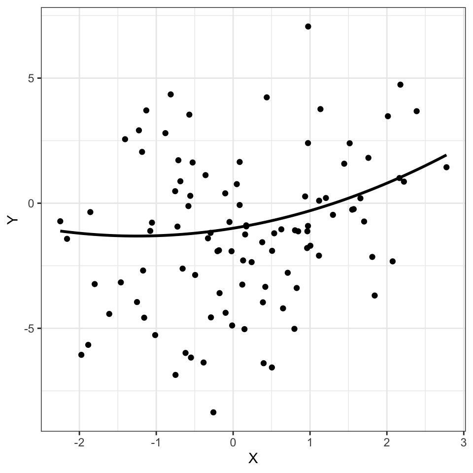

```r
ggplot(aes(X, Y), data=data2) +
geom_point() +
geom_smooth(aes(y=tr_pop$Y), se=FALSE, color="black")
```

## c. Fit three polynomial regression models using least squares: linear, quadratic, and cubic. Produce another scatterplot, add the fitted lines and true population line $f(x)$ using different colors, and add a legend that maps the line color to a model.

- Note: The true model is quadratic, but we are also fitting linear (less complex) and cubic (more complex) models.

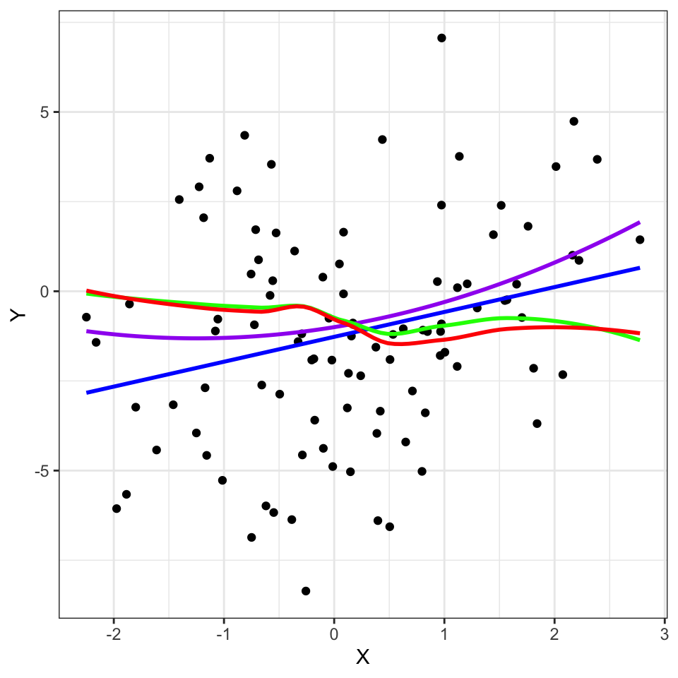

```r
data2 %>%
  ggplot(aes(X, Y)) +
  geom_point() +
  geom_smooth(aes(y=tr_pop$Y), se=FALSE, color="purple") +
  geom_smooth(method="lm",se=FALSE,color="blue") +
  geom_smooth(aes(y=pred2), se=FALSE, color = "green") +
  geom_smooth(aes(y=pred3), se=FALSE, color = "red")
```

## d. Simulate a *test data* set of 10,000 observations from the same distributions. Use `set.seed(612)` prior to generating the test data.

- Calculate the estimated mean squared error (MSE) for each model.
- Are the results as expected?

My MSEs were as follows: linear model = 9.22, quadratic model = 9.17, cubic model = 9.28. I generally expected these results due to bias/variance tradeoff with increasing model complexity. The MSE of the linear model is likely higher because it has too much bias. The MSE of the quadratic model goes down as expected with the introduction of more variables, and the MSE of the cubic model spikes up past the linear model, likely due to higher variance. Also, the original data was generated using a quadratic model, so a quadratic model should have the lowest MSE.

```r
## MSE for each function

mse1=mean((data3$Y-data3$pred1)^2)
mse2=mean((data3$Y-data3$pred2)^2)
mse3=mean((data3$Y-data3$pred3)^2)

## Tibble for data

df=tibble(mse1,mse2,mse3)
df
```

| mse1 | mse2 | mse3 |
| --- | --- | --- |
| 9.222 | 9.172 | 9.278 |

```r
## True population

tr_pop=tibble(X=data3$X,
              Y=-1+0.5*X+.2*(X^2))
tr_pop
```

| X | Y |
| --- | --- |
| -0.2373908 | -1.1074245 |
| 1.1891499 | -0.1226096 |
| 0.7948274 | -0.4762362 |
| 1.4895202 | 0.1884942 |
| -0.7672217 | -1.2658850 |
| 0.8244054 | -0.4518684 |
| -1.0053801 | -1.3005322 |
| -1.6202088 | -1.2850891 |
| -1.3770352 | -1.3092724 |
| 1.7854399 | 0.5302791 |

[output cut: 9990 more lines]

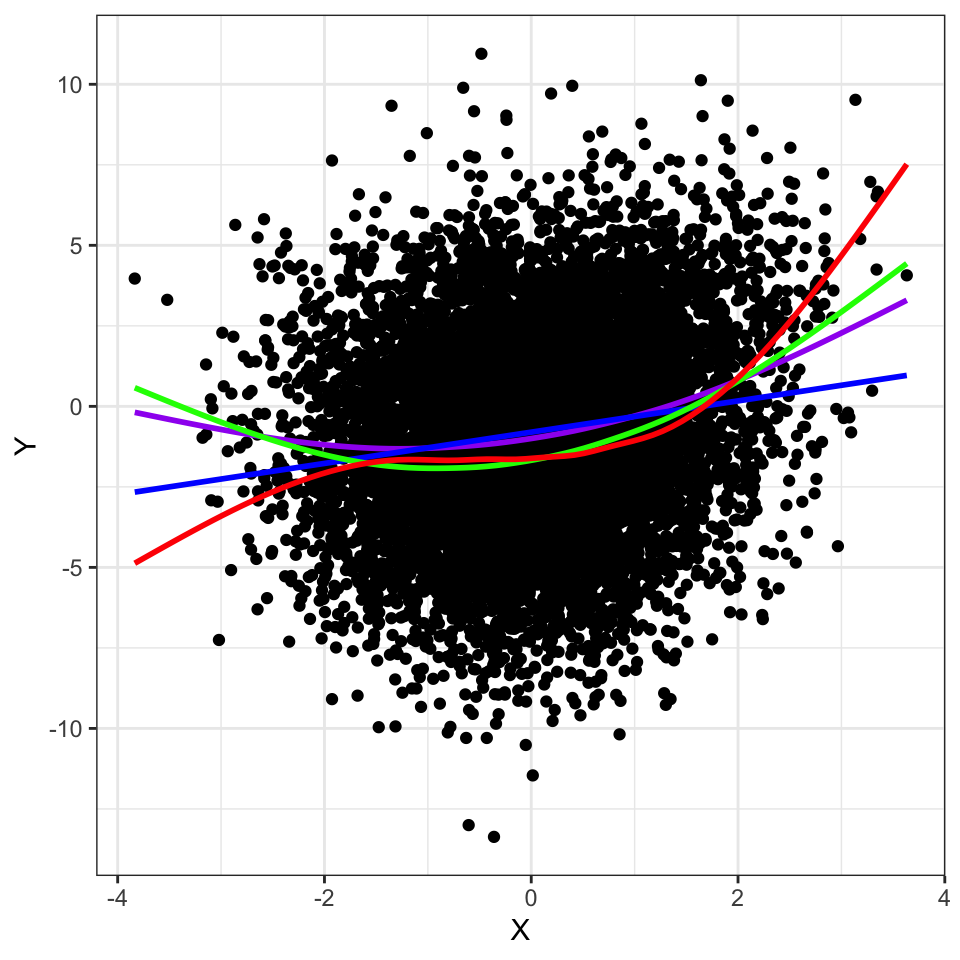

```r
data3 %>%
  ggplot(aes(X, Y)) +
  geom_point() +
  geom_smooth(aes(y=tr_pop$Y), se=FALSE, color="purple") +
  geom_smooth(method="lm",se=FALSE,color="blue") +
  geom_smooth(aes(y=pred2), se=FALSE, color = "green") +
  geom_smooth(aes(y=pred3), se=FALSE, color = "red")
```

## e. What is the best achievable MSE? That is, what is the MSE if the true $f(x)$ was used to evaluate the test set? How close does the best method come to achieving the optimum?

Because the data was generated from a gaussian distribution with a standard deviation of 3, the best achievable MSE is 9 (3*3), since this represents the irreducible error. The quadratic model achieved an MSE of 9.172, which is very close.

## f. The MSE scores obtained in part *d* came from one realization of training data. Here will we explore how much variation there is in the MSE scores by replicating the simulation many times.

- Re-run parts b. and c. (i.e., generate training data and fit models) 100 times.
- Calculate the MSE for all simulations.
- Create kernel density or histogram plots of the resulting MSE values for each model.
- Use `set.seed(613)` prior to running the simulation and do not set the seed in any other places.
- Use the same test data from part d. (This question is only about the variability that comes from the training data).

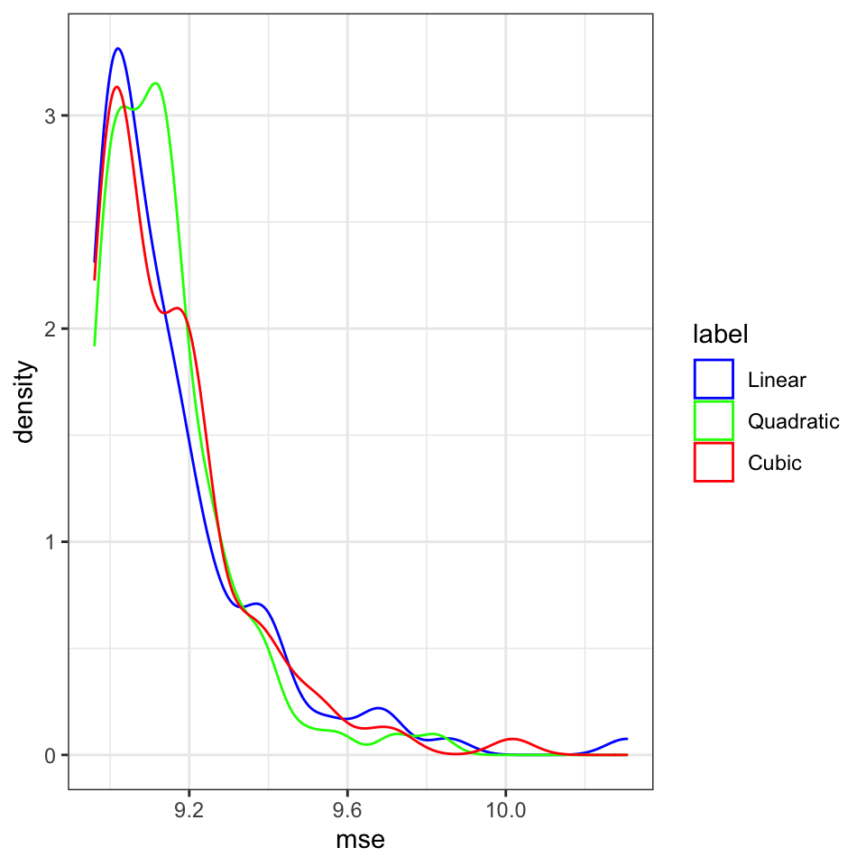

```r
## Visuals

ggplot(data = new, aes(mse,color=label)) +
  geom_density(position="identity") +
  scale_color_manual(labels = c("Linear", "Quadratic","Cubic"),values=c("Blue","Green", "Red"))
```

## g. Show a count of how many times each model was the best. That is, out of the 100 simulations, count how many times each model had the lowest MSE.

| mse | label | mse_lin | mse | label | mse_quad |
| --- | --- | --- | --- | --- | --- |
| 9.291 | 1 | 9.291 | 9.040 | 2 | 9.040 |
| 9.114 | 1 | 9.114 | 9.107 | 2 | 9.107 |
| 9.064 | 1 | 9.064 | 9.113 | 2 | 9.113 |
| 9.856 | 1 | 9.856 | 8.991 | 2 | 8.991 |
| 9.101 | 1 | 9.101 | 9.823 | 2 | 9.823 |
| 9.032 | 1 | 9.032 | 9.062 | 2 | 9.062 |
| 9.138 | 1 | 9.138 | 8.965 | 2 | 8.965 |
| 8.991 | 1 | 8.991 | 9.144 | 2 | 9.144 |
| 9.257 | 1 | 9.257 | 9.131 | 2 | 9.131 |
| 8.993 | 1 | 8.993 | 8.996 | 2 | 8.996 |

[output cut: 90 more lines]

| lin_wins | quad_wins | cub_wins |
| --- | --- | --- |
| 40 | 27 | 33 |

## h. Repeat the simulation in part *f*, but use $\sigma=2$. Report the number of times each model was best (you do not need to produce any plots). Use the same `set.seed(613)` prior to running the simulation and do not set the seed in any other places.

```r
grouped_df1
```

| lin_wins | quad_wins | cub_wins |
| --- | --- | --- |
| 40 | 28 | 32 |

## i. Repeat *h*, but now use $\sigma=4$ and $n=300$.

```r
grouped_df1
```

| lin_wins | quad_wins | cub_wins |
| --- | --- | --- |
| 37 | 30 | 33 |

## j. Describe the effects $\sigma$ and $n$ has on selection of the best model? Why is the *true* model form (i.e., quadratic) not always the *best* model to use when prediction is the goal?

Increasing sigma changes the dispersion of the training data, which introduces variance. This lowers the predictive accuracy of high complexity models especially, due to overfitting. Increasing sample size of the training data reduced the variance within more complex models, but this might not always be true. At the end of the day, true model might not always be the best model to use when prediction is the goal because we don’t care about the traininig data fit - we care about how low the MSE is on the test data. If the parameters of the test data are different, we can result in high training-fit models that are sub-optimal for predictive purposes, and vice versa.